# Banking crisis without panics

Matthew Baron, Emil Verner, Wei Xiong

Feburary 2021 @ QJE

#### Two theories of banking crisis

1. Depositor crisis: depositors claim their deposits from banks that banks failed to honor (liquidity crisis)
2. Capital crisis: adverse shocks (asset losses) impair bank equity and constrain bank’s capacity to finance the economy (solvency crisis)

This paper uses bank equity returns to study banking crisis:

1. Bank equity has the lowest payoff priority, therefore equity returns are sensitive to bank losses.
2. Bank equity returns provide an objective real-time measure not subject to lookback biases.
3. Bank equity returns capture “quiet” crises that involve no panics and are hard to detect otherwise.

#### Data

1. Annual bank and nonbank stock returns date back to 1870.
2. Monthly series in a three-years window around each crisis episode: stock returns, credit spreads.
3. Narrative accounts of crises defined by other authors.

#### Emprical results

**Are large bank equity decline associated with adverse macroeconomic consequence?**

$$\Delta_h y_{i,t+h} = \alpha_{i}^h + \sum_j\beta_j^h\mathbb{1}[r_{i,t}^B \in B_j]
+ \sum_j\delta_j^h\mathbb{1}[r_{i,t}^N \in B_j] + \Gamma^hX_{it} + \epsilon_{it}^h$$

$r_{i,t}^B$: return of bank stocks; $r_{i,t}^N$: return of nonbank stocks; $B_j$: bins of stock returns: -45%, -30%, -15%,…; $X_{it}$: lags of GDP growth, credit-to-GDP change, lags of equity returns. Result: declines in bank equity of greater than 45% predict 3.6% lower output after three years.

Why do bank equity declines predict lower future GDP growth? Bank-lending channel. Repeat the above model with credit-to-GDP as dependent variable: bank equity decline of over 45% predicts a 12ppt decline in credit-to-GDP.

**Are panics necessary for banking crisis to have severe economic consequence?**

Not all bank equity crashes necessarily involve panics. Classify each episode as “panic” or “nonpanic”.

$$\Delta_h y_{i,t+h} = \alpha_{i}^h + \beta_1^h\mathbb{1}[r_{i,t}^B \leq\theta]
+\beta_2^h \text{Panic}_{i,t} + \beta_3^h\mathbb{1}[r_{i,t}^B \leq\theta]\times
\text{Panic}_{i,t} + \Gamma^hX_{it} + \epsilon_{it}^h$$

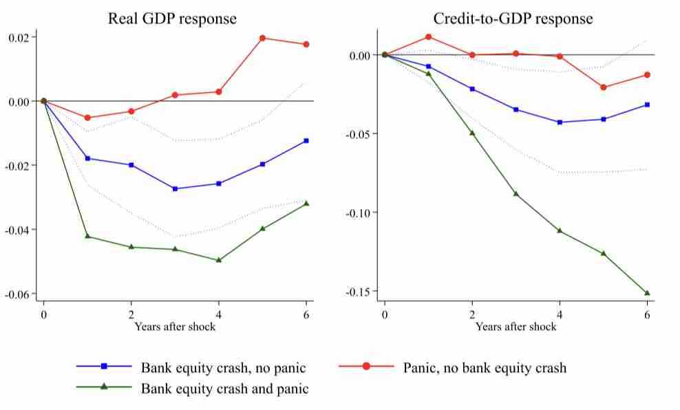

Impulse response of real GDP growth

What if equity market crash due to sentiment but not fundamental changes? Refine the sample to only those periods with narrative evidence of widespread bank failures. The results are similar.

Conclusion: though panics are important amplification mechanism, panics are not necessary for banking crises to have severe economic consequences.

#### Relative timing of bank equity crashes

Bank equity crashes before other indicators:

- 7.46 months before panic
- 2.85 months before earliest narrative starts
- 3.44 months before 1% spike in bank credit spread
- 4.26 months before 1% spike in corp credit spread
- 1.94 months before nonfinancial equity crash

#### Conclusion

1. Bank equity is particularly informative about severe negative macroeconomic events involving a decline in intermediate credit.
2. Banking crisis may occur when banks are under-capitalized and their ability to lend is severely impaired, even when panics by bank creditors are prevented.
3. The importance of timely recapitalization of bank capital during early phases of banking distress, rather than having policies simply backstop liquidity.

© Original paper: [download](https://doi.org/10.1093/qje/qjaa034)